# Análise Exploratória dos Dados

EDA das avaliações humanas referente as reclamações direcionadas a ANAC e ao INSS.

## 1. Realizando tratamento nos dados

### 1.1. Inserindo colunas comprimento da reclamacao e do titulo

```r
reclamacoes <- reclamacoes %>% mutate(reclamacao.length = str_length(reclamacao),
                                      titulo.length = str_length(titulo))
```

### 1.4. Insere coluna com número de letras em capslock

```r
reclamacoes$numero.de.capslock <- str_count(reclamacoes$reclamacao, "\\b[A-Z]{2,}\\b")
```

```r
reclamacoes$numero.de.exclamacoes <- str_count(reclamacoes$reclamacao, "!")
```

## 2. O formato das distribuições dos tamanhos dos títulos e das reclamações por órgão

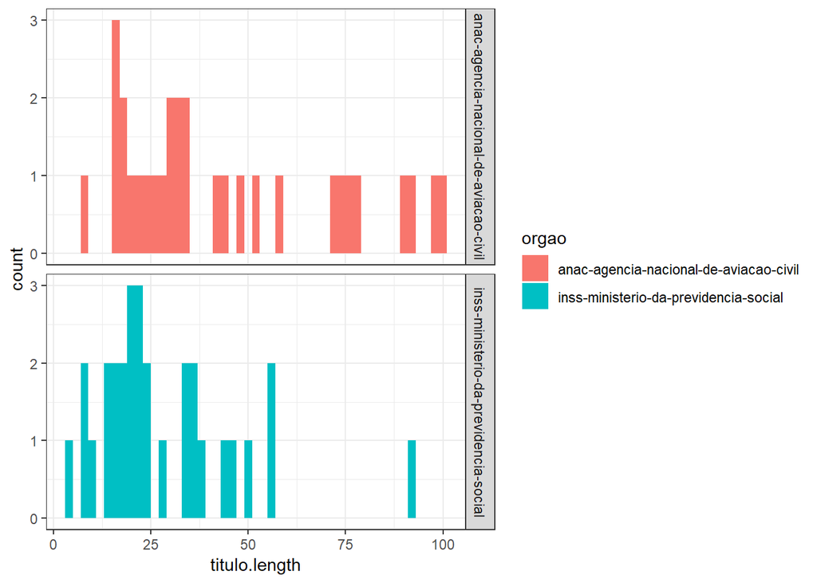

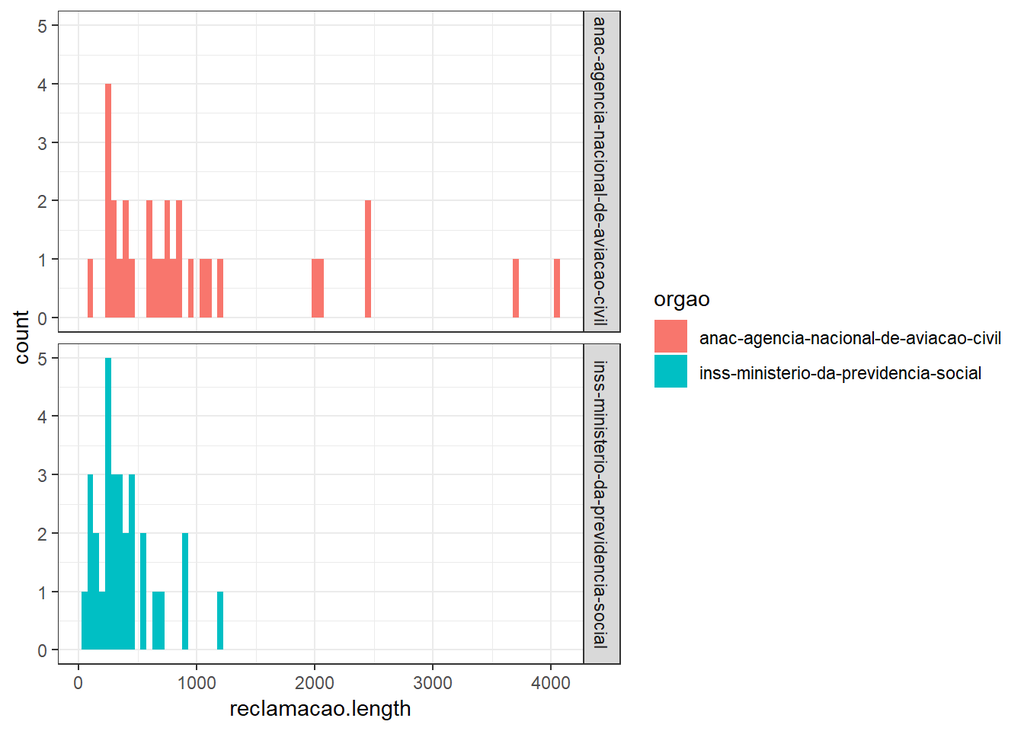

Percebemos que as reclamações do INSS são em média menores do que as reclamações da ANAC.

## 3. Confiabilidade das avaliações humanas

### 3.1. Alguma avaliação foge dos valores de 1 a 5?

```
## # A tibble: 32 x 3
##    avaliador    id insatisfacao
##        <dbl> <dbl>        <dbl>
##  1 115211093     1            1
##  2 115111901     2            4
##  3 115110295     3            1
##  4 115110951     4            2
##  5 115210534     5            2
##  6 115111577     1            1
##  7 116110219     5            1
##  8 115111135     1            2
##  9 115110057     3            4
## 10 115211593     4            2
## # ... with 22 more rows
```

As avaliações estão dentro do intervalo permitido.

### 3.2. Das avaliações realizadas, quantas foram feitas para cada nível de insatisfação?

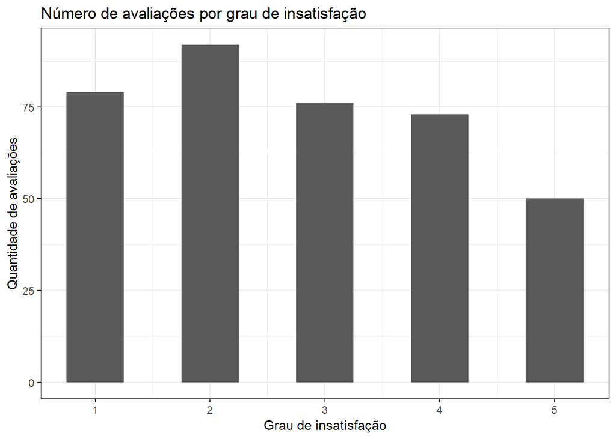

### 3.3. Quantas avaliações foram feitas por reclamação?

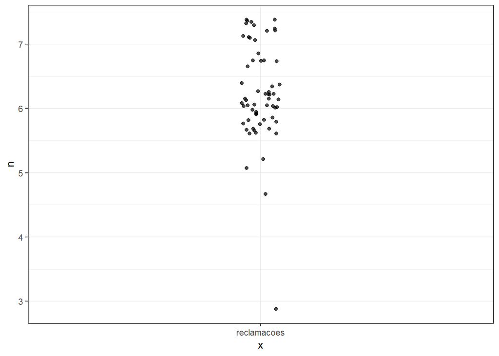

### 3.4. Em média, quantas avaliações por reclamação?

```
## # A tibble: 1 x 2
##   media mediana
##   <dbl>   <int>
## 1  6.21       6
```

Cada reclamação recebeu um número de avaliações próximo das restantes. Isso se verifica analisando o gráfico do tópico 3.3 que tem apenas uma anomalia.

### 3.5. Qual o número de revisores por reclamação?

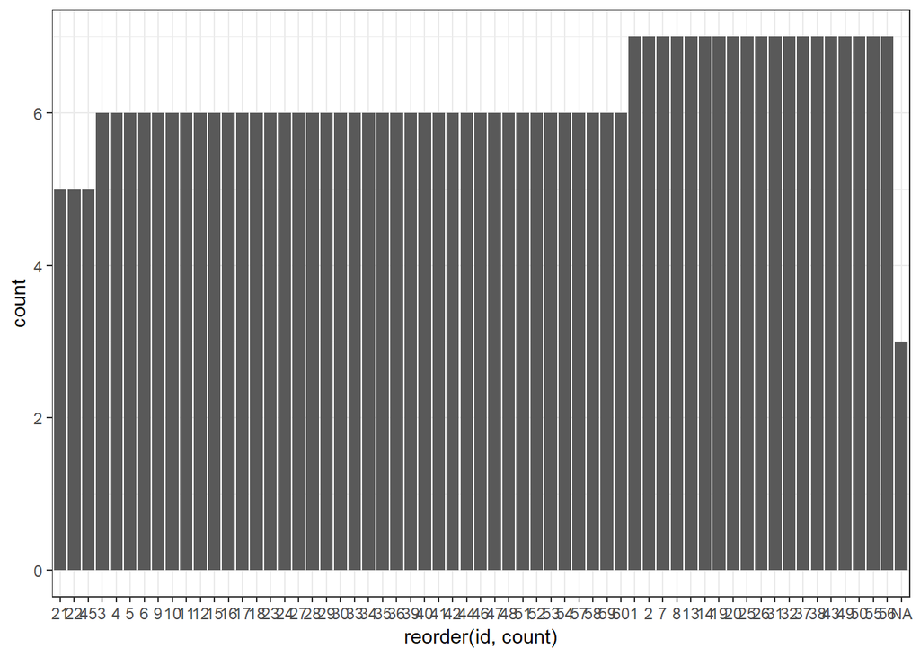

Cada reclamação foi avaliada por um intervalo de 5 à 7 pessoas, com exceção de uma que recebeu 3 avaliações.

## 4. Será que há consenso entre as avaliações de cada reclamação?

### 4.1. Níveis de discordância X id da reclamação

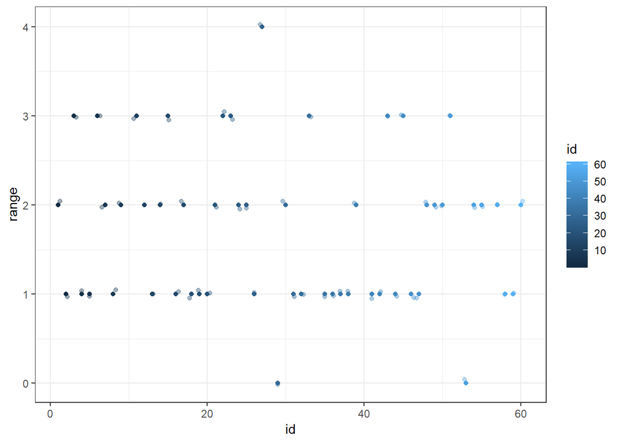

### 4.2. Níveis de discordância X nível médio de insatisfação

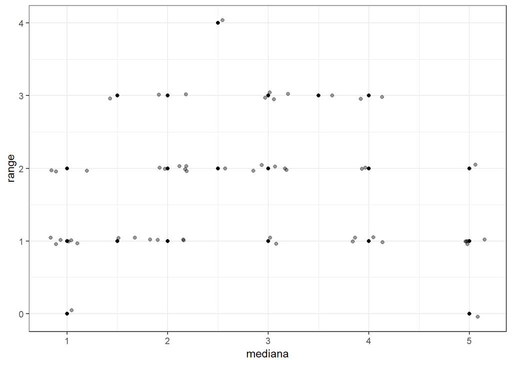

Não parece haver relação entre essas variáveis

### 4.3. A maioria das avaliações tem nível de discordância de 1 e 2

```
## # A tibble: 6 x 2
## # Groups:   range [6]
##   range     n
##   <dbl> <int>
## 1     0     2
## 2     1    23
## 3     2    18
## 4     3    10
## 5     4     1
## 6    NA     7
```

### 4.4. Quantas reclamações tem discordância maior que 2?

```
## # A tibble: 1 x 1
##       n
##   <int>
## 1    11
```

## 5. Será que o tamanho das reclamações, quantidade de exclamações e de letras maiúsculas tem alguma relação com o nível de insatisfação?

### 5.1. Ver proporção do tamanho da reclamação para cada nível de insatisfação em relação a ANAC e INSS

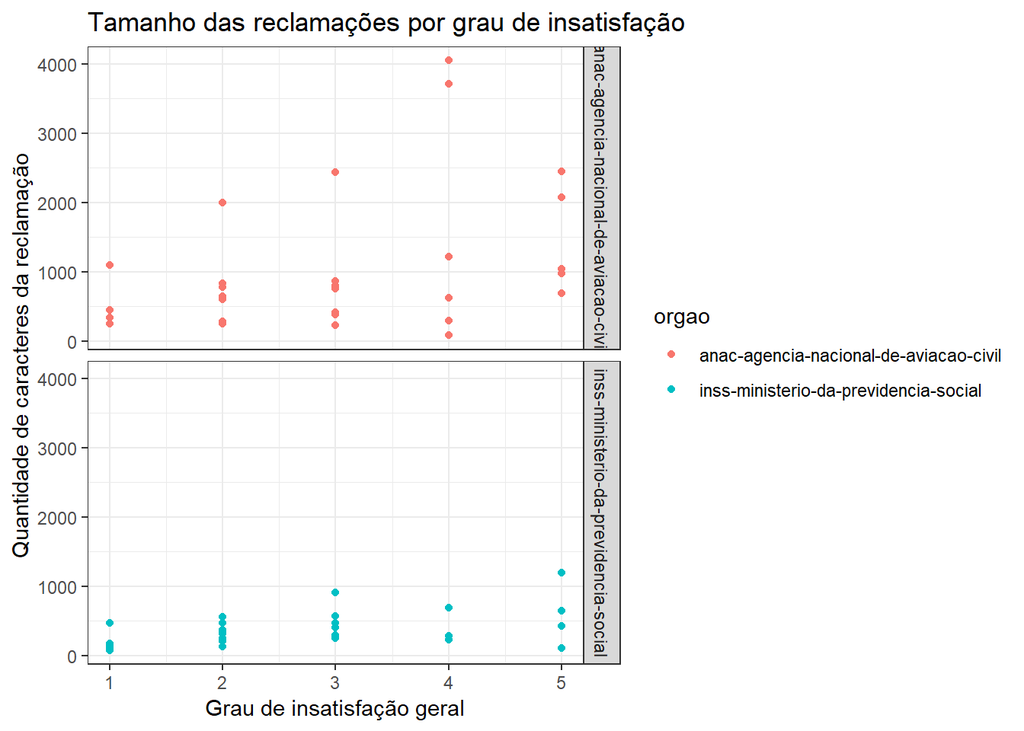

```
##       cor_anac  cor_inss
## [1,] 0.3785455 0.4503986
```

### 5.2. Ver proporção da quantidade de exclamações pra cada nível de insatisfação em relação a ANAC e INSS

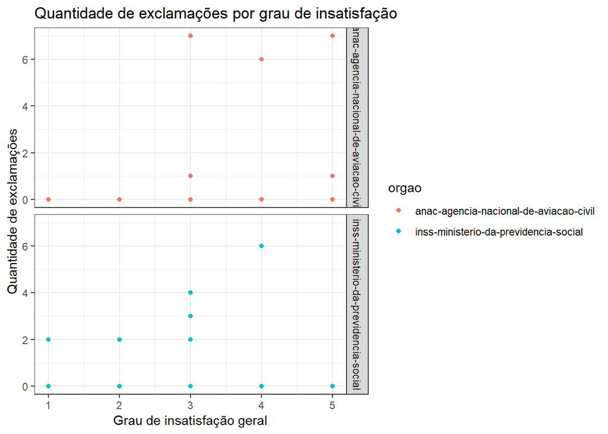

```
##       cor_anac  cor_inss
## [1,] 0.2854496 0.1072848
```

### 5.3. Ver proporção da quantidade de letras maiúsculas pra cada nível de insatisfação em relação a ANAC e INSS

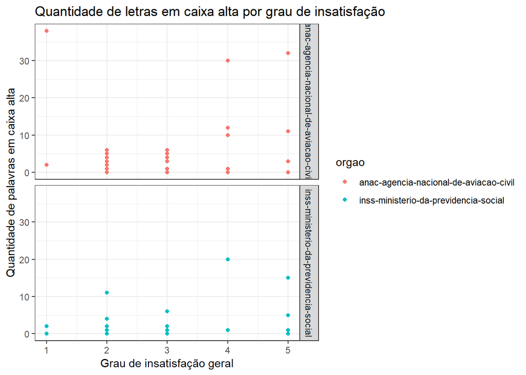

```
##       cor_anac cor_inss
## [1,] 0.1124749 0.361033
```

Nenhuma das análises do tópico 5 apresentou alguma forte correlação entre as variáveis testadas.